# Practical Machine Learning Course- Assignment

This assignment uses data from *Ugulino, Wallace, et al.* “Wearable computing: accelerometers’ data classification of body postures and movements.” *Advances in Artificial Intelligence-SBIA 2012. Springer Berlin Heidelberg, 2012. 52-61.*

The dataset consists of data for six people who were equipped with accelerometers whilst performing a weight lifting exercise. Numerous parameters were recorded. The dumbells were also equipped with accelormeters. They performed the exercises in five ways. Only one way was correct. The goal of this assignment is to seee if the five methods used can be detected using the accelorometers. In the dataset the 5 methods are the variable ‘classe’ and assigned as ‘A’, ‘B’, ‘C’, ‘D’ or ‘E’.

### Data Preparation

The neccessary packages are loaded and the data is read into dataframes.

```r
library(caret)
library(psych)
library(reshape2, ggplot2)
library(randomForest)

weightsTrain  <- read.csv('pml-training.csv',
                          header = TRUE)
weightsTest  <- read.csv('pml-testing.csv',
                          header = TRUE)
```

Create training, validation and test data sets

```r
set.seed(10)

inTrain = createDataPartition(weightsTrain$X, p = 0.7, list = FALSE)
training = weightsTrain[ inTrain,]
validate = weightsTrain[-inTrain,]
testing <- weightsTest
```

Remove columns with incomplete data

```r
training.complete <- training[,!sapply(training,function(x) any(is.na(x)))]
```

### Examination of Variables

The training dataset is examined to find suitable varibles to be used in a prediction model. Histograms are produced and a sample is shown below.

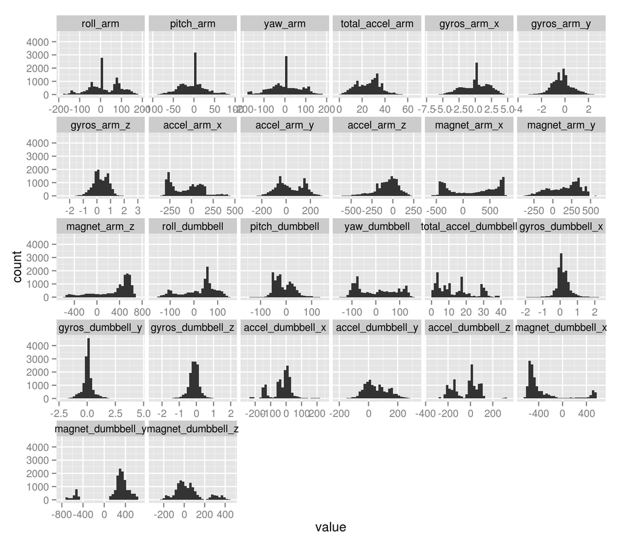

```r
        d <- melt(training.complete[,c(30:70)])
        ggplot(d,aes(x = value)) +
        facet_wrap(~variable,scales = "free_x") +
        geom_histogram()
```

From the histograms the variables that have numerous peaks, which may correspond to the 5 classes, are chosen.

```r
training.complete.cut <- training.complete[c(8,9,10,11,24,25,26,30,31,32,33,49,
        50,51,65,66,67,71,72,73,87,88,89,93)]
```

the variables are:

```r
colnames(training.complete.cut)
```

```
##  [1] "roll_belt"        "pitch_belt"       "yaw_belt"
##  [4] "total_accel_belt" "accel_belt_x"     "accel_belt_y"
##  [7] "accel_belt_z"     "roll_arm"         "pitch_arm"
## [10] "yaw_arm"          "total_accel_arm"  "roll_dumbbell"
## [13] "pitch_dumbbell"   "yaw_dumbbell"     "accel_dumbbell_x"
## [16] "accel_dumbbell_y" "accel_dumbbell_z" "roll_forearm"
## [19] "pitch_forearm"    "yaw_forearm"      "accel_forearm_x"
## [22] "accel_forearm_y"  "accel_forearm_z"  "classe"
```

Make sure all datasets contain the same columns.

```r
validate.complete.cut <- validate[,colnames(training.complete.cut)]
testing.complete.cut <- testing[,colnames(training.complete.cut)[-24]]
```

A check of the suitability of the variables is done using principal component analysis

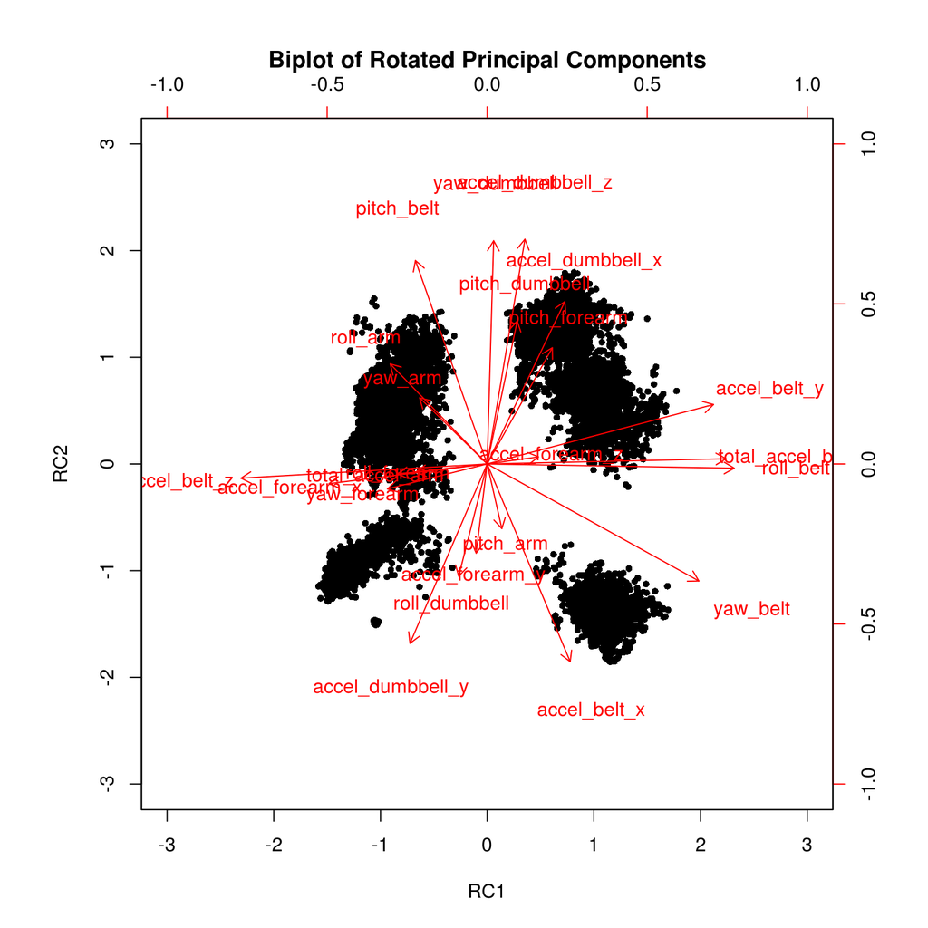

```r
pc <- principal(r = training.complete.cut[,-24], nfactors = 2, rotate = 'varimax')
biplot(pc, main = 'Biplot of Rotated Principal Components')
```

From the plot it appears that the variables can seperate the data set into 5 groups.

### Model Buildng

A random forest calssifier is now built using the selected variables.

```r
RFmodel <- randomForest(classe ~ .,
      data=training.complete.cut,
      ntree=50,
      mtry=4,
      importance=TRUE,
      na.action=na.roughfix,
      replace=FALSE)

RFmodel
```

```
##
## Call:
##  randomForest(formula = classe ~ ., data = training.complete.cut,      ntree = 50, mtry = 4, importance = TRUE, replace = FALSE,      na.action = na.roughfix)
##                Type of random forest: classification
##                      Number of trees: 50
## No. of variables tried at each split: 4
##
##         OOB estimate of  error rate: 1.29%
## Confusion matrix:
##      A    B    C    D    E class.error
## A 3873    7    3    3    1 0.003601749
## B   29 2618   22    1    1 0.019842756
## C    2   31 2364   16    0 0.020306672
## D    1    1   31 2177    3 0.016267510
## E    0   10    6    9 2529 0.009788567
```

The model does extemely well on the training data so there is no need to refine it at this stage.

### Validation

The model is now tried on the validation data:

```r
predictionsVal <- predict(RFmodel, validate.complete.cut)
confusionMatrix(predictionsVal, validate.complete.cut$classe)
```

```
## Confusion Matrix and Statistics
##
##           Reference
## Prediction    A    B    C    D    E
##          A 1688   12    1    0    0
##          B    3 1109    8    0    0
##          C    0    5  992   16    0
##          D    2    0    8  986    5
##          E    0    0    0    1 1048
##
## Overall Statistics
##
##                Accuracy : 0.9896
##                  95% CI : (0.9867, 0.9921)
##     No Information Rate : 0.2877
##     P-Value [Acc > NIR] : < 2.2e-16
##
##                   Kappa : 0.9869
##  Mcnemar's Test P-Value : NA
##
## Statistics by Class:
##
##                      Class: A Class: B Class: C Class: D Class: E
## Sensitivity            0.9970   0.9849   0.9832   0.9831   0.9953
## Specificity            0.9969   0.9977   0.9957   0.9969   0.9998
## Pos Pred Value         0.9924   0.9902   0.9793   0.9850   0.9990
## Neg Pred Value         0.9988   0.9964   0.9965   0.9965   0.9990
## Prevalence             0.2877   0.1914   0.1715   0.1705   0.1790
## Detection Rate         0.2869   0.1885   0.1686   0.1676   0.1781
## Detection Prevalence   0.2891   0.1903   0.1722   0.1701   0.1783
## Balanced Accuracy      0.9970   0.9913   0.9894   0.9900   0.9975
```

The prediction model is now run against the test data.

```r
predictionsTest <- predict(RFmodel, testing.complete.cut)
predictionsTest
```

```
##  1  2  3  4  5  6  7  8  9 10 11 12 13 14 15 16 17 18 19 20
##  B  A  B  A  A  E  D  B  A  A  B  C  B  A  E  E  A  B  B  B
## Levels: A B C D E
```

The test predictions were submitted with a result of 20/20, confirming the accuracy of the model.